# **Data Science Pipeline Tutorial: Analyzing Police Shootings from 2015 to 2020**

CMSC320 Spring 2021

Written and Coded by Rohan Angajala and Anu Basil

### Introduction

Welcome to our tutorial through the data science pipeline. For this tutorial, we walk through important steps in data manipulation, exploratory data analysis, investigating trends and testing hypothesis. The topic we study to perform this analysis is one that is a very relevant and heavily discussed topic in recent times. We examine data on police shootings from 2015 to 2020. Each row of the data corresponds to an individual shooting and includes information such as date of the shooting, as well as race and age demographics about the alleged perpetrator that was shot. Our intent is not to draw conclusions about police shootings based on this data such as claiming that a certain variable definitely increases the likelihood of being shot, but rather to investigate the trends across the data and make observations about the shootings that could then potentially be used in the future.

Let's get started!

### Data Collection

First, we will need to read in our dataset using the Pandas library. We use a dataset from Kaggle.com, a popular machine learning and data science website. You can find the dataset here: https://www.kaggle.com/ahsen1330/us-police-shootings.

Download the CSV file from this website and import it into the current directory. Afterwards, we read in the csv file into a Pandas DataFrame with pd.read_csv.

```python
import pandas as pd
import numpy as np
import matplotlib.pyplot as plt
data = pd.read_csv("shootings.csv")
data.head()
```

|  | id | name | date | manner_of_death | armed | age | gender | race | city | state | signs_of_mental_illness | threat_level | flee | body_camera | arms_category |
| --- | --- | --- | --- | --- | --- | --- | --- | --- | --- | --- | --- | --- | --- | --- | --- |
| 0 | 3 | Tim Elliot | 2015-01-02 | shot | gun | 53.0 | M | Asian | Shelton | WA | True | attack | Not fleeing | False | Guns |
| 1 | 4 | Lewis Lee Lembke | 2015-01-02 | shot | gun | 47.0 | M | White | Aloha | OR | False | attack | Not fleeing | False | Guns |
| 2 | 5 | John Paul Quintero | 2015-01-03 | shot and Tasered | unarmed | 23.0 | M | Hispanic | Wichita | KS | False | other | Not fleeing | False | Unarmed |
| 3 | 8 | Matthew Hoffman | 2015-01-04 | shot | toy weapon | 32.0 | M | White | San Francisco | CA | True | attack | Not fleeing | False | Other unusual objects |
| 4 | 9 | Michael Rodriguez | 2015-01-04 | shot | nail gun | 39.0 | M | Hispanic | Evans | CO | False | attack | Not fleeing | False | Piercing objects |

We provide this command to upgrade the Matplotlib package just in case you are on a older version as some features of the plots covered in this tutorial are only visible on newer versions of Matplotlib.

```python
!pip install -U matplotlib
```

### Data Management/Representation

Let's start by checking if there are any necessary modifications to consider in our data (e.g. missing data). Missing or malicious data can be problematic because as we move into plotting and data analysis, these values can cause unintended consequences, or in the case of missing values that show up as NaN, it could cause errors. Let's first check for NaN values with the following command.

```python
data[data.isna().any(axis=1)]
```

|  | id | name | date | manner_of_death | armed | age | gender | race | city | state | signs_of_mental_illness | threat_level | flee | body_camera | arms_category |
| --- | --- | --- | --- | --- | --- | --- | --- | --- | --- | --- | --- | --- | --- | --- | --- |

Great! So we don't have missing data. Checking the unique values of some of the columns however revealed that there is an inconsistency in the data in the age column. See below and notice the 37.1179309 which is not a non-decimal age like all the other unique ages in the dataset.

```python
data['age'].unique()
```

```
array([53.       , 47.       , 23.       , 32.       , 39.       ,
       18.       , 22.       , 35.       , 34.       , 25.       ,
       31.       , 41.       , 30.       , 37.       , 28.       ,
       42.       , 36.       , 49.       , 71.       , 33.       ,
       29.       , 43.       , 24.       , 75.       , 68.       ,
       27.       , 48.       , 21.       , 67.       , 19.       ,
       54.       , 17.       , 56.       , 61.       , 45.       ,
       26.       , 40.       , 59.       , 38.       , 51.       ,
       74.       , 57.       , 46.       , 16.       , 50.       ,
       20.       , 77.       , 37.1179309, 58.       , 64.       ,
       52.       , 63.       , 44.       , 60.       , 66.       ,
       83.       , 72.       , 76.       , 62.       , 55.       ,
       69.       , 15.       , 65.       ,  6.       , 12.       ,
       70.       , 80.       , 14.       , 82.       , 13.       ,
       73.       , 91.       , 79.       , 78.       , 84.       ,
       81.       ])
```

```python
data.loc[data['age'] == 37.11793090137039]
```

|  | id | name | date | manner_of_death | armed | age | gender | race | city | state | signs_of_mental_illness | threat_level | flee | body_camera | arms_category |
| --- | --- | --- | --- | --- | --- | --- | --- | --- | --- | --- | --- | --- | --- | --- | --- |
| 126 | 584 | Alejandro Salazar | 2015-02-20 | shot | gun | 37.117931 | M | Hispanic | Houston | TX | False | attack | Car | False | Guns |
| 644 | 789 | Roger Albrecht | 2015-08-29 | shot | knife | 37.117931 | M | White | San Antonio | TX | False | other | Not fleeing | False | Sharp objects |
| 692 | 839 | Lawrence Price | 2015-09-17 | shot | gun | 37.117931 | M | White | Brodhead | KY | False | attack | Not fleeing | False | Guns |
| 750 | 908 | Jason Day | 2015-10-12 | shot | gun | 37.117931 | M | Black | Lawton | OK | False | attack | Not fleeing | False | Guns |
| 797 | 964 | Deaunte Lamar Bell | 2015-10-29 | shot | gun | 37.117931 | M | Black | Columbus | OH | False | other | Not fleeing | False | Guns |
| ... | ... | ... | ... | ... | ... | ... | ... | ... | ... | ... | ... | ... | ... | ... | ... |
| 4695 | 5665 | Christopher Mullins | 2020-03-13 | shot | knife | 37.117931 | M | White | Mufreesboro | TN | False | other | Not fleeing | False | Sharp objects |
| 4744 | 5718 | Michael Leon Hammett | 2020-04-05 | shot | knife | 37.117931 | M | White | Ada | OK | True | attack | Not fleeing | False | Sharp objects |
| 4759 | 5737 | Matt Goff | 2020-04-10 | shot | gun | 37.117931 | M | White | Klamath Falls | OR | False | attack | Car | False | Guns |
| 4773 | 5675 | Derick L. Powe | 2020-04-17 | shot | gun | 37.117931 | M | Black | Daphne | AL | True | attack | Not fleeing | False | Guns |
| 4866 | 5845 | TK TK | 2020-05-29 | shot | toy weapon | 37.117931 | M | White | Lancaster | CA | False | attack | Other | False | Other unusual objects |

85 rows × 15 columns

From the above analysis, there seems to be just one inconsistent age, and there are 85 rows of it so it seems that it is some kind of error in data gathering and unlikely that there are 85 people whose age is exactly 37 years and 0.117931 of a year. We will elect to ignore this data since it is unclear what may have caused this entry and whether it is meant to be 37 years or some other value.

```python
data = data[data['age'] != 37.11793090137039]
```

Now let's add some columns to our dataframe that will be useful when performing exploratory data analysis. Let's start by adding a year column by using some regex to scrape the year from the date column.

```python
data['year'] = data['date'].str[:data['date'].str.index('-')[0]] #Use regex to locate relevant part of string
```

```python
data
```

|  | id | name | date | manner_of_death | armed | age | gender | race | city | state | signs_of_mental_illness | threat_level | flee | body_camera | arms_category | year |
| --- | --- | --- | --- | --- | --- | --- | --- | --- | --- | --- | --- | --- | --- | --- | --- | --- |
| 0 | 3 | Tim Elliot | 2015-01-02 | shot | gun | 53.0 | M | Asian | Shelton | WA | True | attack | Not fleeing | False | Guns | 2015 |
| 1 | 4 | Lewis Lee Lembke | 2015-01-02 | shot | gun | 47.0 | M | White | Aloha | OR | False | attack | Not fleeing | False | Guns | 2015 |
| 2 | 5 | John Paul Quintero | 2015-01-03 | shot and Tasered | unarmed | 23.0 | M | Hispanic | Wichita | KS | False | other | Not fleeing | False | Unarmed | 2015 |
| 3 | 8 | Matthew Hoffman | 2015-01-04 | shot | toy weapon | 32.0 | M | White | San Francisco | CA | True | attack | Not fleeing | False | Other unusual objects | 2015 |
| 4 | 9 | Michael Rodriguez | 2015-01-04 | shot | nail gun | 39.0 | M | Hispanic | Evans | CO | False | attack | Not fleeing | False | Piercing objects | 2015 |
| ... | ... | ... | ... | ... | ... | ... | ... | ... | ... | ... | ... | ... | ... | ... | ... | ... |
| 4890 | 5916 | Rayshard Brooks | 2020-06-12 | shot | Taser | 27.0 | M | Black | Atlanta | GA | False | attack | Foot | True | Electrical devices | 2020 |
| 4891 | 5925 | Caine Van Pelt | 2020-06-12 | shot | gun | 23.0 | M | Black | Crown Point | IN | False | attack | Car | False | Guns | 2020 |
| 4892 | 5918 | Hannah Fizer | 2020-06-13 | shot | unarmed | 25.0 | F | White | Sedalia | MO | False | other | Not fleeing | False | Unarmed | 2020 |
| 4893 | 5921 | William Slyter | 2020-06-13 | shot | gun | 22.0 | M | White | Kansas City | MO | False | other | Other | False | Guns | 2020 |
| 4894 | 5924 | Nicholas Hirsh | 2020-06-15 | shot | gun | 31.0 | M | White | Lawrence | KS | False | attack | Car | False | Guns | 2020 |

4810 rows × 16 columns

Perfect! Now as you can see in the rightmost column we have values organized by year. Now, let's add a column which categorizes individual shootings by the age group of the alleged perpetrator. That is, let's group up all our ages into groups such as 0-20 years old, 20-40 years old, etc., and assign each shooting the appropriate age group based on the age column. Pandas.cut is useful for this task. We'll assign cut values 1,2,3,4,5 to represent groups age 0-20, 20-40, 40-60, 60-80, and 80-100, respectively.

```python
#create new column named cut to store age ranges
data['cut'] = pd.cut(data['age'], [0,20,40,60,80,100], right=True, labels = [1.0, 2.0, 3.0, 4.0, 5.0])
data
```

|  | id | name | date | manner_of_death | armed | age | gender | race | city | state | signs_of_mental_illness | threat_level | flee | body_camera | arms_category | year | cut |
| --- | --- | --- | --- | --- | --- | --- | --- | --- | --- | --- | --- | --- | --- | --- | --- | --- | --- |
| 0 | 3 | Tim Elliot | 2015-01-02 | shot | gun | 53.0 | M | Asian | Shelton | WA | True | attack | Not fleeing | False | Guns | 2015 | 3.0 |
| 1 | 4 | Lewis Lee Lembke | 2015-01-02 | shot | gun | 47.0 | M | White | Aloha | OR | False | attack | Not fleeing | False | Guns | 2015 | 3.0 |
| 2 | 5 | John Paul Quintero | 2015-01-03 | shot and Tasered | unarmed | 23.0 | M | Hispanic | Wichita | KS | False | other | Not fleeing | False | Unarmed | 2015 | 2.0 |
| 3 | 8 | Matthew Hoffman | 2015-01-04 | shot | toy weapon | 32.0 | M | White | San Francisco | CA | True | attack | Not fleeing | False | Other unusual objects | 2015 | 2.0 |
| 4 | 9 | Michael Rodriguez | 2015-01-04 | shot | nail gun | 39.0 | M | Hispanic | Evans | CO | False | attack | Not fleeing | False | Piercing objects | 2015 | 2.0 |
| ... | ... | ... | ... | ... | ... | ... | ... | ... | ... | ... | ... | ... | ... | ... | ... | ... | ... |
| 4890 | 5916 | Rayshard Brooks | 2020-06-12 | shot | Taser | 27.0 | M | Black | Atlanta | GA | False | attack | Foot | True | Electrical devices | 2020 | 2.0 |
| 4891 | 5925 | Caine Van Pelt | 2020-06-12 | shot | gun | 23.0 | M | Black | Crown Point | IN | False | attack | Car | False | Guns | 2020 | 2.0 |
| 4892 | 5918 | Hannah Fizer | 2020-06-13 | shot | unarmed | 25.0 | F | White | Sedalia | MO | False | other | Not fleeing | False | Unarmed | 2020 | 2.0 |
| 4893 | 5921 | William Slyter | 2020-06-13 | shot | gun | 22.0 | M | White | Kansas City | MO | False | other | Other | False | Guns | 2020 | 2.0 |
| 4894 | 5924 | Nicholas Hirsh | 2020-06-15 | shot | gun | 31.0 | M | White | Lawrence | KS | False | attack | Car | False | Guns | 2020 | 2.0 |

4810 rows × 17 columns

### Exploratory Data Analysis

Now we can use powerful tools across Pandas and Matplotlib to investigate some trends based on the data we have. Let's start by examining the number of shootings by gender.

```python
#create arrays to store rows of male and female victims separately
male_arr = []
female_arr = []
for index,row in data.iterrows():
    if row['gender'] == 'M':
        male_arr.append(row)
    else:
        female_arr.append(row)
```

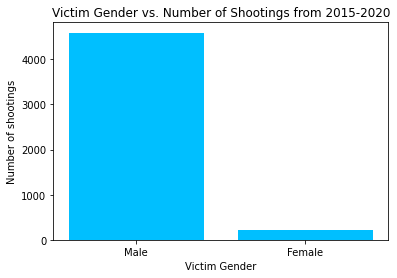

```python
#set up values for bar graph to use later
data_male_female = {'Male':len(male_arr), 'Female':len(female_arr)}
courses = list(data_male_female.keys())
values = list(data_male_female.values())

# creating the bar plot
plt.bar(courses, values, color ='deepskyblue')

plt.xlabel("Victim Gender")
plt.ylabel("Number of shootings")
plt.title("Victim Gender vs. Number of Shootings from 2015-2020")
plt.show()
```

Here we have a bar graph of the gender vs. number of shootings. This shows us that there are a disproportionate number of male victims that were shot by police. We can see that there are over 4000 males in our data set but only less than 500 females. Assuming that all other things are equal, we can see there likely is a higher chance that the shot victim is male.

Let's now look into trends relating to age and year in our data.

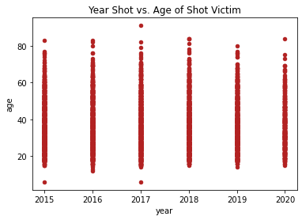

```python
#create scatter plot
data.plot(kind='scatter', x='year', y='age', color="firebrick", title= "Year Shot vs. Age of Shot Victim")
```

We graphed a scatter plot of the year of each shooting vs. the age of the victim. We can see here that there is not much of a difference in age range of these victims over the years, which a few small exceptions. There was an older person shot in 2017 than all other years. Also, 2017 and 2015 both had an unusually young victim. This being said, there is little differences in the age of shot victims over the years as seen in this graph. It might be more beneficial if we could see the numbers of victims in a certain age group. For example, maybe there were more younger victims in earlier years and older victims in later years. This is not something that we can tell from this graph.

A better way to represent this plot would be as a violin plot. A violin plot is a type of plot that allows you to show multiple distributions within one plot, where each distribution appears in the format of a distribution curve that allows you to see the modes where the most data values lie. Each distribution is also a type of boxplot however, showing the spread of data and using markers to represent different quartiles. Let's do a violin plot of year vs. age below.

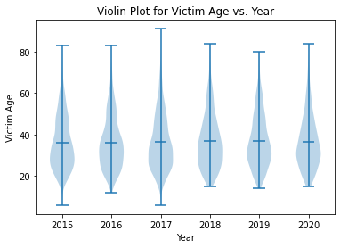

```python
#group by year
year_group = data.groupby ('year')
yearly_ages = year_group.apply(lambda x: list(x['age']))

#create violin plot
plt.violinplot(yearly_ages.values,list(map(int,list(yearly_ages.index))),widths=0.5,showmeans=True)
plt.xlabel("Year")
plt.ylabel("Victim Age")
plt.title("Violin Plot for Victim Age vs. Year")
plt.show()
```

The curves associated with each distribution tell us which ages show up most often in those distributions. It would appear that these modes are roughly the same across all the years, between 30 and 40 years old. We can see that 2017 had slightly more spread in age but this was due to outliers beyond age 80 (since the distribution of data is very low beyond age 50). So, based on this we can observe that the ages of police shooting victims has not changed noticeably with time.

Can we find that age is changing with respect to some other variable? Let's find out! Let's create a violin plot again, this time using the state that the shootings occurred in as the x-axis and still plotting age distributions.

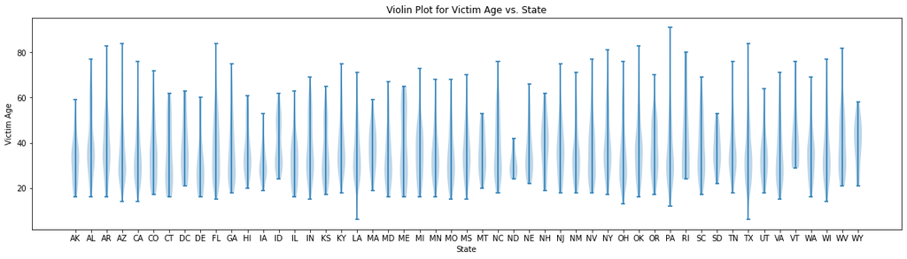

```python
year_group = data.groupby('state') #group by year
yearly_ages = year_group.apply(lambda x: list(x['age'])) #obtain age data from groupby objects
fig, ax = plt.subplots(figsize=(20,5))

#Create violin plot
ax.violinplot(yearly_ages.values,positions=range(len(list(yearly_ages.index))))
plt.xticks(range(len(list(yearly_ages.index))),list(yearly_ages.index))
plt.xlabel("State")
plt.ylabel("Victim Age")
plt.title("Violin Plot for Victim Age vs. State")
plt.show()
```

Many of the states seem to have roughly the same age distribution, but there are definitely some unique distributions. Maine, for example, seems to have a pretty even spread of killings across ages, whereas states like Vermont and Iowa are a lot more skewed towards younger ages. It's also interesting to see that North Dakota has a very concentrated killing distribution around age 30-35.

Let's investigate a little further. Let's introduce a different variable from our dataset, race, and start by seeing how the totals for shootings change over time.

```
['Asian', 'White', 'Hispanic', 'Black', 'Other', 'Native']
```

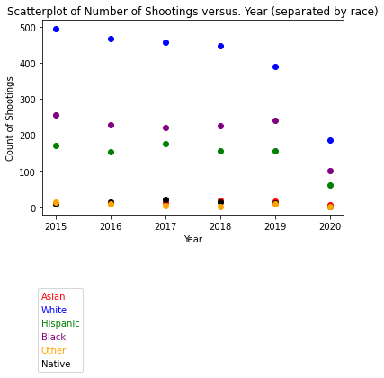

```python
colors = ['red','blue','green','purple','orange','black']
yr_races = data.groupby(['year','race']) #group by year and race
print(list(data['race'].unique()))
color_map = dict(zip(list(data['race'].unique()),colors)) #map colors to races
fig, ax = plt.subplots()
for key,item in yr_races:
  plt.scatter(((int)(key[0])),len(yr_races.get_group(key)),c=color_map[key[1]],label=key[1])
leg = plt.legend(labels=data['race'].unique(),handletextpad=0, handlelength=0,bbox_to_anchor=(0.15, -0.35),labelcolor=colors)
for label in leg.legendHandles: #create custom legend
  label.set_visible(False)
plt.xlabel("Year")
plt.ylabel("Count of Shootings")
plt.title("Scatterplot of Number of Shootings versus. Year (separated by race)")
plt.show()
```

White people seem to have the highest total instances of being involved in police shootings across all the years, with Blacks next, then Hispanics, and the remaining categories being roughly the same. It is interesting to observe the large dip in number of shootings in 2020. It's hard to say what caused this for sure, but it's interesting to ponder some potential reasons such as the coronavirus pandemic and the stay-at-home orders.

Let's now construct violin plots to make more conclusions about the specific distributions with respect to age. We will make one plot per the three most frequent races showing up in our data.

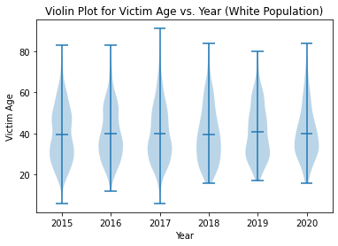

```python
#Same process as earlier
year_group = data.groupby(['year','race']) #group by year
yearly_ages = year_group.apply(lambda x: list(x['age']))
values = []
for a in yearly_ages.index:
  if a[1] == 'White': #isolate by race
    values.append(yearly_ages[a])
plt.violinplot(values,list(map(int,list(data['year'].unique()))),widths=0.5,showmeans=True)
plt.xlabel("Year")
plt.ylabel("Victim Age")
plt.title("Violin Plot for Victim Age vs. Year (White Population)")
plt.show()
```

It would seem that most of the killings for the White population have perpetrators of around age 37, but that there is still quite a lot of data for older ages from 50 to 60.

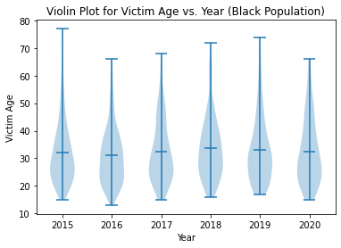

```python
year_group = data.groupby(['year','race']) #group by year
yearly_ages = year_group.apply(lambda x: list(x['age']))
values = []
for a in yearly_ages.index:
  if a[1] == 'Black': #isolate by race
    values.append(yearly_ages[a])
plt.violinplot(values,list(map(int,list(data['year'].unique()))),widths=0.5,showmeans=True)
plt.xlabel("Year")
plt.ylabel("Victim Age")
plt.title("Violin Plot for Victim Age vs. Year (Black Population)")
plt.show()
```

The comparison between the last plot and this one is pretty interesting. The modes of the distribution are leaning to younger ages, most of the modes being around 25 years of age. There are also much fewer killings among older ages than there are for the White population. It would appear that the among the data, Black people are shot more among younger ages but White people are shot more in later adult years.

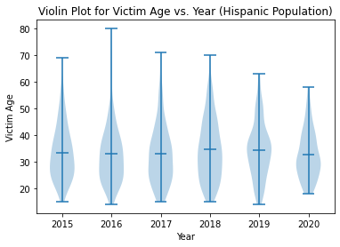

```python
year_group = data.groupby(['year','race']) #group by year
yearly_ages = year_group.apply(lambda x: list(x['age']))
values = []
for a in yearly_ages.index:
  if a[1] == 'Hispanic': #isolate by race
    values.append(yearly_ages[a])
plt.violinplot(values,list(map(int,list(data['year'].unique()))),widths=0.5,showmeans=True)
plt.xlabel("Year")
plt.ylabel("Victim Age")
plt.title("Violin Plot for Victim Age vs. Year (Hispanic Population)")
plt.show()
```

From this plot, we can see that the distributions are more even and the counts of killings by age cover a much large span from around 25 to 40 for earlier years. The last two years seem to show data centering more around the 35-40 range of age, which could be an indication that older Hispanics are being shot more in recent years, but it is difficult to interpret given that the trend is in the last 2 years of the data.

Let's take a look at a bar chart representation that is another visually telling way of observing trends in age by race.

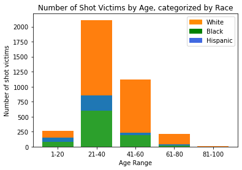

```python
data['cut'] = pd.cut(data['age'], [0,20,40,60,80,100], right=True, labels = [1.0, 2.0, 3.0, 4.0, 5.0])
labels = ['1-20', '21-40', '41-60', '61-80', '81-100']

#group by race and cut
new_data = data.groupby(['race', 'cut']).size()

#create variables to store all the values for each race that we are looking at
black_ages = [new_data['Black'][0], new_data['Black'][1], new_data['Black'][2], new_data['Black'][3], new_data['Black'][4]]
white_ages = [new_data['White'][0], new_data['White'][1], new_data['White'][2], new_data['White'][3], new_data['White'][4]]
hispanic_ages = [new_data['Hispanic'][0], new_data['Hispanic'][1], new_data['Hispanic'][2],
                 new_data['Hispanic'][3], new_data['Hispanic'][4]]
width = 0.35       # the width of the bars: can also be len(x) sequence


#create segmented bar graph
fig, ax = plt.subplots()

ax.bar(labels, black_ages)
ax.bar(labels, white_ages, bottom=black_ages)
ax.bar(labels, hispanic_ages,)

plt.xlabel("Age Range")
plt.ylabel("Number of shot victims")
plt.title("Number of Shot Victims by Age, categorized by Race")

colors = {'White':'darkorange', 'Black':'green', 'Hispanic':'royalblue'}
labels = list(colors.keys())
handles = [plt.Rectangle((0,0),1,1, color=colors[label]) for label in labels] #create rectangle colored keys in legend
plt.legend(handles, labels)
```

Here we separated the victims by age group and race. Based on this graph, we can see that the majority of people shot in our data are people between the ages of 21 and 40. We can also see that majority of these people are white. Some other parts of this graph are also worth noting. In the age group 1-20, we can see that there is about the same number of people being killed of each race that we have taken into account. We must notice that we have not taken into account the population of each race here. So, we see that there are about the same number of each race being shot by police but proportionally, there are much more black and hispanic people of this age group that are being shot. We can also see that between the age groups of 21-40 and 41-60, the number of black and hispanic people being shot decreased by more than half. However, the number of white people being shot has decreased only a little bit. We can also see that by the time people reach the 81-100 age group, there are very few people being shot, but we can also see that most of these people are also white.

The plots examining age and race were very informative. Let's take a look at some other variables and see what other insights we can draw. Below, we will use Matplotlib's segmented bar chart after gathering data for armed and unarmed status by age. We are trying to examine trends relating to age and whether or not perpetrators of that age were armed when they were shot by police.

```python
age_group = data.groupby('age') #group by age
age_dict = {} #dictionary to keep track of armed counts per age
for row in age_group.armed.value_counts().index:
  if row[0] not in age_dict:
    age_dict[row[0]] = [0,0]
  val0 = age_dict[row[0]][0]
  val1 = age_dict[row[0]][1]
  if row[1] == 'unarmed': #increment if unarmed
    val0 += 1
  else: #armed count
    val1 += 1
  age_dict[row[0]] = [val0, val1]
```

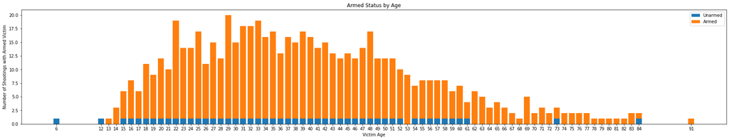

```python
labels = list(age_dict.keys())
labels = [(int)(x) for x in labels]
unarmed_counts = [v[0] for v in age_dict.values()] #retrieve appropriate dictionary values
armed_counts = [v[1] for v in age_dict.values()] #retrieve appropriate dictionary values
fig, ax = plt.subplots(figsize=(30,5))
plt.xticks(labels)

#Plot Segmented Bar Chart
ax.bar(labels, unarmed_counts, label='Unarmed')
ax.bar(labels, armed_counts, bottom=unarmed_counts,
       label='Armed')

ax.set_ylabel('Armed Status')
ax.set_title('Armed Status by Age')
ax.legend()
ax.set_xlabel("Victim Age")
ax.set_ylabel("Number of Shootings with Armed Victim")

plt.show()
```

It would seem that from our analysis so far, demographics information has proven useful to look like, such as age distributions varying by race. So, let's introduce another similar variable from our data, state, which we can access from the column we created earlier in the tutorial. Let's create a bar chart to view the number of police shootings by state in the 5 year span.

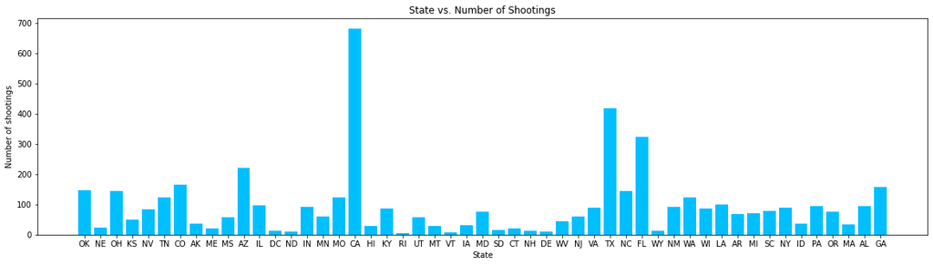

```python
plt.figure(figsize=(20,5))
cts = data['state'].value_counts(sort=False) #get number of shootings (rows of data) per state
plt.bar(cts.index, cts.values, color ='deepskyblue') #Plot counts
plt.xlabel("State")
plt.ylabel("Number of shootings")
plt.title("State vs. Number of Shootings")
plt.show()
```

This chart provides us with a great visualization of the number of shootings by state. It's easy to see that California has the most number of shootings, and then Texas and Florida follow. States like Rhode Island and state capitol Washington D.C. are among the states with the lowest number of police shootings. While we can't say for sure, it is reasonable to assume that this trend might have something to do with the populations and sizes of these states. California, Texas and Florida are among the largest states in the United States, and Rhode Island is among the smallest. Washington D.C., being a city, undoubtedly is small in size too. So, the above graphic, while interesting to look at, isn't really a great way for us to compare number of police shootings across states individually, because we can't make sense of other kinds of trends due to this large contributing factor of population size (a larger population could mean more criminals which could mean more shootings).

To be able to compare number of shootings across states meaningfully, we will introduce *standardization* into our data analysis. Standardizing against a variable, in our case the state, will allow us to compare number of shootings on the same scale, rather than have the large outliers such as California due to reasons such as population. In the following code excerpt, we will take the number of shootings for a given year,state combination, and subtract the average number of shootings in that state across the 5 years from it, and then take this result and divide by the standard deviation of the shootings in that state. This is the standard methodology used when computing standardized scores for a variable.

```python
#Group by state and year, and gather corresponding counts of data
standard_df = data.groupby(['state','year']).size().reset_index().rename(columns={0:'count'})
avg_ct = standard_df.groupby('state')['count'].mean() #calculate averages per state
std_dev = standard_df.groupby('state')['count'].apply(np.std) #calculate standard deviations per state
standardized_counts = []
#Assembling standardized count of killings by state with following formula:
# ((number of shootings in year i in state j) - (average # of shootings in state j)) / (std. dev of shootings in state j)
for i in range(0,len(standard_df['year'])):
  x = standard_df['count'][i]
  standardized_counts.append((x-avg_ct[standard_df['state'][i]])/std_dev[standard_df['state'][i]])
standard_df['standardized_counts'] = standardized_counts
standard_df
```

|  | state | year | count | standardized_counts |
| --- | --- | --- | --- | --- |
| 0 | AK | 2015 | 4 | -2.000000 |
| 1 | AK | 2016 | 6 | 0.000000 |
| 2 | AK | 2017 | 7 | 1.000000 |
| 3 | AK | 2018 | 7 | 1.000000 |
| 4 | AK | 2019 | 6 | 0.000000 |
| ... | ... | ... | ... | ... |
| 289 | WY | 2015 | 5 | 1.477098 |
| 290 | WY | 2016 | 2 | -0.369274 |
| 291 | WY | 2017 | 1 | -0.984732 |
| 292 | WY | 2018 | 4 | 0.861640 |
| 293 | WY | 2019 | 1 | -0.984732 |

294 rows × 4 columns

Let's now plot the obtained standardized scores for number of shootings across states. In our plot, 0 would represent the mean (since standardization is essentially a way of creating a normal distribution centered at 0), so states below it would have relatively lower number of police shootings on this new scale we obtained, and states above it would have a higher number of police shootings on the scale.

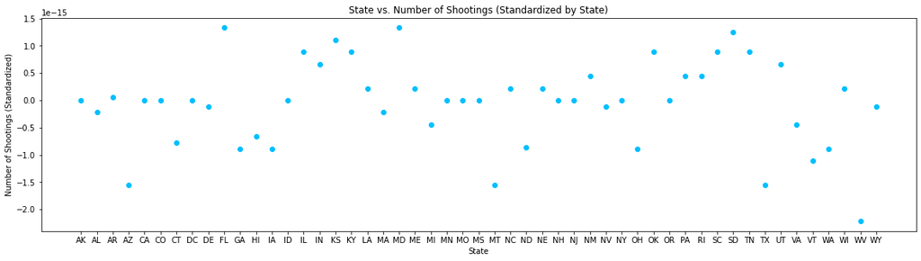

```python
#now bar chart with standardized counts
cts = standard_df.groupby(['state'])['standardized_counts'].sum() #sum up for cumulative count across individual states
#Killings vs. State
plt.figure(figsize=(20,5))
plt.scatter(cts.index, cts.values, color ='deepskyblue')
plt.xlabel("State")
plt.ylabel("Number of Shootings (Standardized)")
plt.title("State vs. Number of Shootings (Standardized by State)")
plt.show()
```

It'll be a really interesting visual display and could help us draw more insights to view these same results on a geographic map. Let's use the Plotly library (similar to Folium) to first view states by killings, then view states by the standardized scores.

```python
#Import necessary libraries
!pip install plotly
!pip install cufflinks
import plotly.graph_objs as go
from plotly.offline import init_notebook_mode,iplot,plot
init_notebook_mode(connected=True)
state_df = pd.DataFrame()
state_df['state'] = sorted(data['state'].unique()) #gather states
state_df['count'] = list(data.groupby('state').size()) #gather corresponding counts
state_df

#Create Choropleth map as dictionary object
d = dict(
        type = 'choropleth',
        colorscale = 'Viridis',
        locations = state_df['state'],
        locationmode = "USA-states",
        z = state_df['count'],
        text = state_df['state'],
        colorbar = {'title' : 'State Counts'},
      )

layout = dict(title = 'Killings by States',
              geo = dict(projection = {'type':'mercator'})
             )
```

```python
#Show resulting choropleth plot
choromap = go.Figure(data = [d],layout = layout)
choromap.update_layout(width=1000,height=1000)
choromap.show()
```

[interactive chart not shown]

This supports the insights from our original plot of killings by state.

```python
cts = standard_df.groupby(['state'])['standardized_counts'].sum() #standardized counts from earlier
d = dict(
        type = 'choropleth',
        colorscale = 'Viridis',
        locations = cts.index,
        locationmode = "USA-states",
        z = cts.values,
        text = cts.index,
        colorbar = {'title' : 'State Counts'},
      )

layout = dict(title = 'Standardized Killings by States',
              geo = dict(projection = {'type':'mercator'})
             )
```

```python
choromap = go.Figure(data = [d],layout = layout)
choromap.update_layout(width=1000,height=1000)
choromap.show()
```

[interactive chart not shown]

Next, we will plot arms category vs the number of shootings involving those arms categories. A bar chart is appropriate to investigate the relative amounts

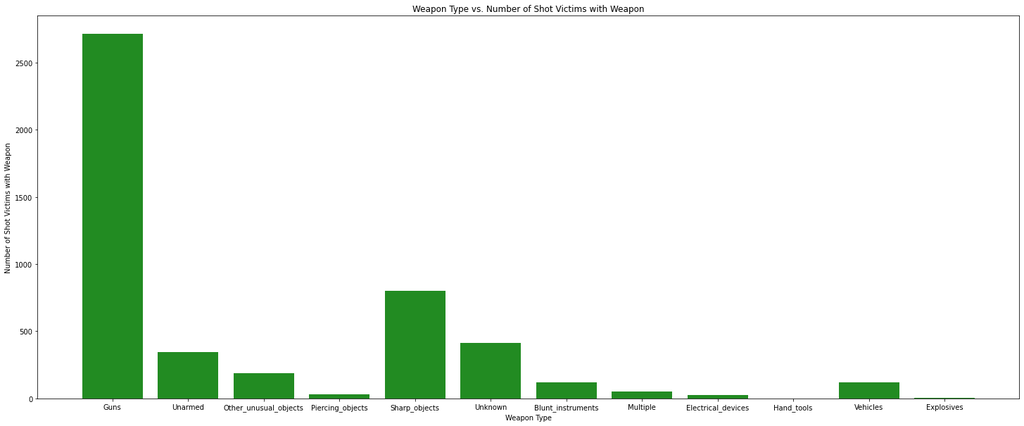

```python
#group by arms category
df = data.groupby('arms_category').size()

#store number of types of attacks
type_of_attack = {'Guns':df[3], 'Unarmed':df[9], 'Other_unusual_objects':df[6],
                'Piercing_objects':df[7],'Sharp_objects':df[8],'Unknown':df[10],
                'Blunt_instruments':df[0],'Multiple':df[5],
                'Electrical_devices':df[1],'Hand_tools':df[4],
                'Vehicles':df[11],'Explosives':df[2]}
keys = list(type_of_attack.keys())
values = list(type_of_attack.values())

# creating the bar plot
f, ax = plt.subplots(figsize=(25,10))
plt.bar(keys, values, color ='forestgreen')

plt.xlabel("Weapon Type")
plt.ylabel("Number of Shot Victims with Weapon")
plt.title("Weapon Type vs. Number of Shot Victims with Weapon")

plt.show()
```

This bar graph shows the number of shot victims with the type of weapon that they had at the time. Based on this data, most of the people that were shot by the police had guns at the time of being shot. The next highest number of weapons is a sharp object, like a knife. Many of the other weapon types did not have a large number of shot victims. We can tell from this graph that, all other things being equal, a person is more likely to be shot by the police if they are holding a gun rather than any other weapon type. This makes sense because police are only supposed to shoot a person if they are a danger to anyone around, having a gun would make them more of a threat, in most situations, than any other weapon type.

We will now graph the race vs. the number of people shot of each race. We are expecting to find that one or two races have been shot more than others. We can predict that there will be more white people being shot by police because there are more white people in the United States. However, there is also a possibility that there are more black people being shot by police.

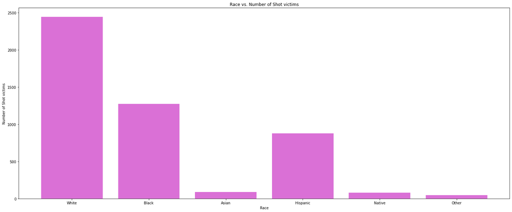

```python
#race vs # of each race

#group by to get sizes of each race
race = data.groupby('race').size()

race_hash = {'White':race[5], 'Black':race[1],'Asian':race[0], 'Hispanic':race[2],
                'Native':race[3],'Other':race[4],}

keys = list(race_hash.keys())
values = list(race_hash.values())

# creating the bar plot
f, ax = plt.subplots(figsize=(25,10))
plt.bar(keys, values, color ='orchid')

#creating labels for graph
plt.xlabel("Race")
plt.ylabel("Number of Shot victims")
plt.title("Race vs. Number of Shot victims")

plt.show()
```

This graph shows the number of people that were shot by each race that was given. Based on this data, we can see that there are significantly more white people being shot than any other race. The next highest would be black people. However, we must also consider that these two races are the most prevalent in the United States. Even so, there are significantly more white people than black people in the United States, therefore it might be worth looking at this graph again, with population taken into account. We will make this graph next, with the y-axis being proportions of number of victims in 2019 relative to the number of members of that race in 2019. We use 2019 because it is the only available, accurate census data from the last five years.

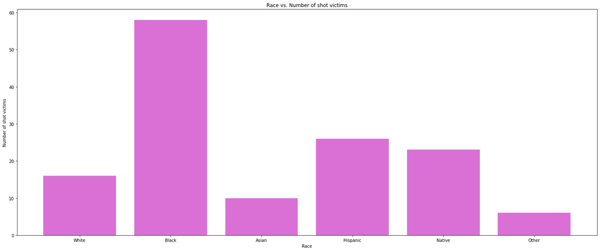

```python
#According to the United States Census Bureau in 2019
#236.5 million white people in the US
#41.99 million black people in the US
#18.64 million asian people in the US
#60 million hispanic people in the US
#5,220,579 native people in the US
#15,553,808 other people in the US

year2019 = data[data['year']=="2019"]

year2019['race']

white = 236500000
black = 41990000
asian = 18640000
hispa = 60000000
nativ = 5220579
other = 15553808

race = year2019.groupby('race').size()

#creating variables to graph
#we are multiplying (the number of shot victims of each race divided by divided by the races population) by the 10000000
#because we want to make sure that all of the values are visible on the bar graph. By multipying by 10000000 we are simply
#making the proportion into a valid number greater than 1 such that we are able to see all the values on the graph.
#If we only used the division without multiplying we would get a very very small number and we would not be able to clearly
#see the proportions of all the races.
w = int(round((race[5]/white)*10000000))
b = int(round((race[1]/black)*10000000))
a = int(round((race[0]/asian)*10000000))
h = int(round((race[2]/hispa)*10000000))
n = int(round((race[3]/nativ)*10000000))
o = int(round((race[4]/other)*10000000))

race_hash = {'White':w, 'Black':b,
             'Asian':a, 'Hispanic':h,
                'Native':n,'Other':o}

keys = list(race_hash.keys())
values = list(race_hash.values())

# creating the bar plot
f, ax = plt.subplots(figsize=(25,10))
plt.bar(keys, values, color ='orchid')

plt.xlabel("Race")
plt.ylabel("Number of shot victims")
plt.title("Race vs. Number of shot victims")

plt.show()
```

This bar graph takes into account the population of race in the United States in 2019. Based on this graph, we can see that the proportion of black people being shot in the United States is higher than the proportion of white people. In the previous graph, it was clear that there were more white people being shot, but if we take into account that there are way more white people in the United States than black people, we can see that more black people are being shot, by the proportion of the population. This graph takes into account only the year 2019 because we could not find population sizes for each race for all years. However, to explain the proportion of races being shot by police officers, we can just use the data from 2019. So, using only the data that we have from 2019 and the population sizes from 2019, we can see that the proportion of black people that were killed was higher than any other race. While in the graph above, we saw that there were a significant number of white people being killed, here we can see that by population, more black people are being killed.

Next, we will graph mental illness vs age range on a bar graph. We want to observe if a person's mental illness could be a reason that the person was shot by the police. Is there a particular age group where people with mental illnesses are shot more or less? Are people with mental illnesses shot by police more than people without mental illnesses?

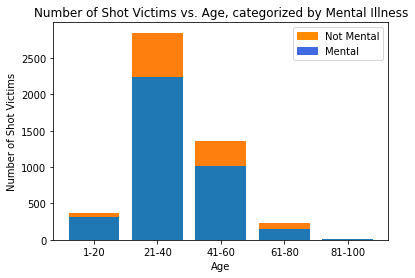

```python
labels = ['1-20', '21-40', '41-60', '61-80', '81-100']

#group by mental illness signs
new_data_mental = data.groupby(['signs_of_mental_illness', 'cut']).size()

#store values of the age groups in both mental and not mental
mental = [new_data_mental[False][0], new_data_mental[False][1], new_data_mental[False][2],
          new_data_mental[False][3], new_data_mental[False][4]]
not_mental = [new_data_mental[True][0], new_data_mental[True][1], new_data_mental[True][2],
          new_data_mental[True][3], new_data_mental[True][4]]

#plot bar graph
fig, ax = plt.subplots()

ax.bar(labels, mental)
ax.bar(labels, not_mental, bottom=mental)

plt.xlabel("Age")
plt.ylabel("Number of Shot Victims")
plt.title("Number of Shot Victims vs. Age, categorized by Mental Illness")

colors = { 'Not Mental':'darkorange', 'Mental':'royalblue'}
labels = list(colors.keys())
handles = [plt.Rectangle((0,0),1,1, color=colors[label]) for label in labels]
plt.legend(handles, labels)
```